# HW04 Part 1: Complete Chapter 3

#### Section 3.8 Questions

**1:** What is the problem with this plot? How could you improve it. *Hint:* Remember the size of the `mpg` data set from earlier in this exercise. Does the number of points seem correct? **Note:** Write the code to improve it.

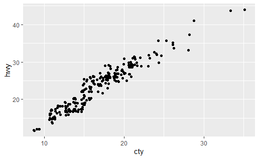

```r
ggplot(data = mpg, mapping = aes(x = cty, y = hwy)) +
  geom_point(position="jitter")
```

adding jitter helps to reveal many overlapped points. By doing this I have a better understanding of where the data is more concentrated.

**2:** What parameters to `geom_jitter()` control the amount of jittering? the width and height parameters of jitter each control both the vertical and horizontal jitter

**3:** Compare and contracts `geom_jitter()` with `geom_count()`.

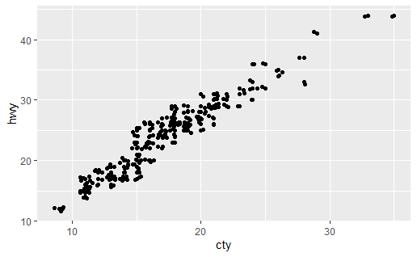

```r
ggplot(data = mpg, mapping = aes(x = cty, y = hwy)) +
  geom_point()+
  geom_jitter()
```

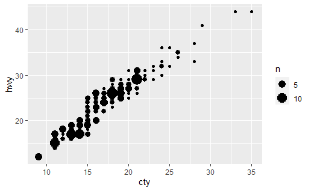

```r
ggplot(data = mpg, mapping = aes(x = cty, y = hwy)) +
  geom_point()+
  geom_count()
```

geom jitter gives us more information about the data by spreading overlapping points while geom count creates larger objects to describe overlapping data points

**4:** What is the default position adjustement for `geom_boxplot()`? Create a visualization of the `mpg` dataset that demonstrates it.

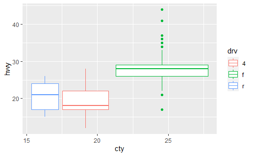

```r
ggplot(data = mpg, mapping = aes(x = cty, y = hwy,color=drv)) +
  geom_boxplot()
```

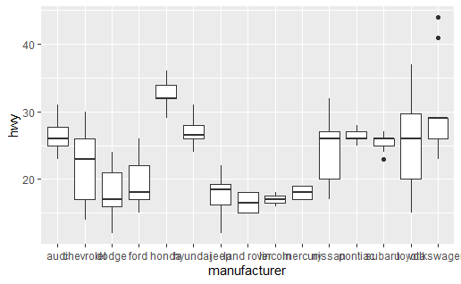

```r
ggplot(data = mpg, mapping = aes(x = manufacturer, y = hwy,group=manufacturer)) +
  geom_boxplot()
```

The default position is vertically aligned box plots

### Section 3.9: Coordinate systems

**Note:** Read about and do only the code chunk associated with `coord_flip()`. `coord_flip()` is a great layer to use when you have categorical data with longish names as it makes the text easier to read.

coord_flip flips the x and y axes. The box plots can be displayed vertically or horizontally.

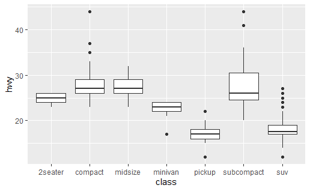

```r
#Vertically arranged
ggplot(data = mpg, mapping = aes(x = class, y = hwy)) +
  geom_boxplot()
```

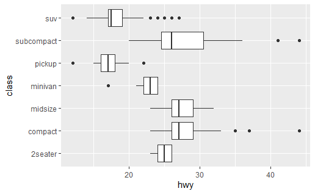

```r
#Horizontally arranged
ggplot(data = mpg, mapping = aes(x = class, y = hwy)) +
  geom_boxplot() +
  coord_flip()
```

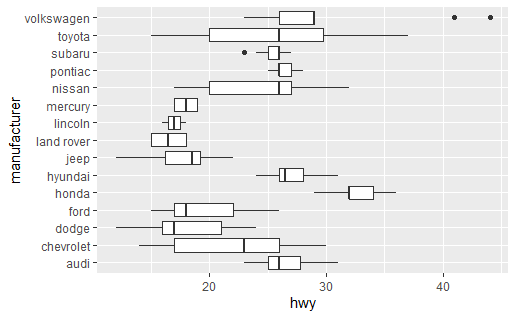

```r
ggplot(data = mpg, mapping = aes(x = manufacturer, y = hwy,group=manufacturer)) +
  geom_boxplot()+
  coord_flip()
```

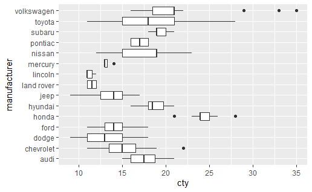

```r
ggplot(data = mpg, mapping = aes(x = manufacturer, y = cty,group=manufacturer)) +
  geom_boxplot()+
  coord_flip()
```

### Section 3.10: The layered grammar of graphics

Just read this section as a contextual review of everything you just learned.